Quin Yuter EDA Project  
MSDS 430 - Python For Data Science  
Dr. Dill  
12/5/2024

[figure not shown]

# Introduction

### Overview of Project

In this Exploratory Data Analysis project, I am looking at Year-by-Year team statistics from Major League Baseball teams. I have chosen six teams: The New York Yankees, the New York Mets, the Los Angeles Dodgers, the Los Angeles Angels, the Chicago Cubs, and the Chicago White Sox. I have chose these six teams because they are from the three largest markets: New York, Los Angeles, and Chicago. I have narrowed down the data to the years 2002 to 2024, as those are the years I have been alive.

My goals for this assignment are as follows:

1. To analyze trend data to evaluate how teams have improved or declined over time and identify which teams have consistently performed at the highest levels.
2. To investigate the relationship between team salary and performance, assessing whether and how financial investment impacts success.

I'd like to look at how the team has performed over time and what statistics are best at showing performance. I think it will be interesting to see if the trends of certain batting statistics match up or are similar to other batting statistics. It will also be interesting to see if the team's batting statistics and fielding statistics are good in the same years. Finally, it will be interesting to see if high payroll yields better performance.

### Project Importance

This project is incredibly important to me. My career goal is to be a data scientist for professional baseball (the dream is to work for the Chicago Cubs). Thus, this project is a sneak peek into what I hopefully will be doing for my entire professional career. By doing an EDA on baseball data, I not only gain deeper insights into how the big market teams have performed over the last 20 years, but I also add a project to my portfolio.

In terms of how this project is important societally, I would say its importance varies on the person. For an everyday person who does not follow baseball, this project is not especially important. For MLB fans, the project provides interesting insights, but it does not affect them in their day to day life. This project is most important for the front offices of the six MLB teams explored in this analysis. This analysis can tell teams multiple things, like in what direction their team is trending in or if salary is a significant predictor/explanatory variable of performance.

### Hypothesis

My first initial hypothesis was that salary does not correlate with success as much as people may think. Because baseball is incredibly streaky in terms of performance, a high-payed player may slump while a low-payed player may shine. Thus, success may rely more on individual trends versus how much they are being paid. I also hypothesize that within a city, each team will trend in opposite directions. One will have high salaries, one will have low, one will perform better, one will perform worse. This is because it is rare for both teams within a city to perform at a high level multiple years in a row.

# Data Explanation

**Baseball Reference** is an online database that compiles data from baseball teams in multiple leagues over multiple years.

**Link To Data:** https://www.baseball-reference.com/teams/CHC/batteam.shtml

### Data Cleaning

Overall, the data was not too messy. I first dropped any null observations (although there were not any, I included this anyways). I had to replace the League Column with a Team column and include the Team name instead of the League. To the blank eye, one would not understand that "NL Central" means the Chicago Cubs, so it is much easier to refer to the teams in other ways. Also, my data started as six different data frames, one for each of the six teams. So, I had to merge all of the data frames together by simply concatenating them together (since they all had the same columns). There were also multiple columns we did not need, like where the team finished, how many games they played (it is always 162), and the average age of the team. So, these columns were dropped. We also dropped any row that was an observation from 2020 because Covid-19 affected the cumulative statistics (the statistics that were not averaged, like doubles and homeruns). I also had to rename many of the columns because someone who does not know baseball would not have known what most of the columns meant. Lastly, I had to change many data types of variables. Most of the float variables needed to be integers instead. Also, salary started as an object.

### Data Dictionary

| Variable Name | Data Type | Definition |
| --- | --- | --- |
| Year | Integer | Year of the baseball season that correlates with that observation and its statistics |
| League | Object | Major League Baseball is divided into two leagues: National League or American League |
| Team | Object | The team that correlates with that observation and its statistics |
| Wins | Integer | The number of wins from the given team in the given year |
| Losses | Integer | The number of losses from the given team in the given year |
| Runs_Per_Game | Float | The average number of runs scored per game from the given team in the given year |
| Plate_Appearances | Integer | The total number of plate appearances from the given team in the given year |
| At_Bats | Integer | The total number of At Bats (Walks, Hit by Pitch, Sacrifice Hits and Sacrifice Flies are not included) from the given team in the given year |
| Runs | Integer | The total number of runs the given team scored in the given year |
| Hits | Integer | The total number of hits the given team hit in the given year |
| Doubles | Integer | The total number of doubles the given team hits in the given year |
| Triples | Integer | The total number of triples the given team hits in the given year |
| HR | Integer | The total number of homeruns the given team hits in the given year |
| RBI | Integer | The total number of runs batted in the given team had in the given year |
| SB | Integer | The total number of stolen bases the given team steals in the given year |
| Caught_Stealing | Integer | The total number of times the given team was caught stealing in the given year |
| Walks | Integer | The total number of times the given team walked in the given year |
| Strikeouts | Integer | The total number of times the given team struckout in the given year |
| Batting_Average | Float | The total number of hits divided by the total number of at-bats |
| On_Base_Percentage | Float | The number of (total hits, hit by pitches, and walks) divided by the number of (at-bats, hit by pitches, walks, and sacrifice flies) |
| Slugging_Percentage | Float | The total number of bases from the given team in the given year (1: Single, 2: Double, 3: Triple, 4: Homerun divided by number of at-bats |
| On_Base_Plus_Slugging | Float | The on base percentage of the given team in the given year added to the slugging percentage of the given team in the given year |
| Errors | Integer | The number of Errors the given team committed in the field in the given year |
| Double_Plays | Integer | The number of double plays the given team turned in the field in the given year |
| Field_Percentage | Float | The number of successful plays made divided by the total chances the given team got in the given year |
| Salary | Integer | The total payroll the players on the given team received as a team in the given year |

# Results

```python
# Reloading modules
import pandas as pd
import numpy as np
import seaborn as sns
import matplotlib.pyplot as plt
import plotly.express as px

# Multiple outputs
from IPython.core.interactiveshell import InteractiveShell
InteractiveShell.ast_node_interactivity = "all"
```

```python
## Reading in Data
bsbl_df = pd.read_csv("total_data_EDA.csv")
```

### Trend Data

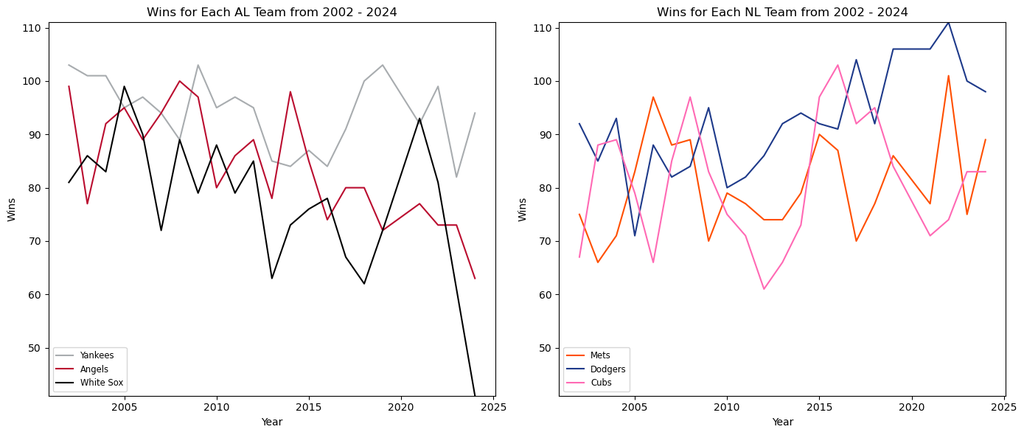

```python
## American League Teams
al = bsbl_df[bsbl_df['Team'].isin(['Angels', 'White Sox', 'Yankees'])]
al_colors = {
    'Angels': '#BA0C2F',
    'White Sox': '#000000',
    'Yankees': '#A8ACAF',
}

# National League Teams
nl = bsbl_df[bsbl_df['Team'].isin(['Dodgers', 'Cubs', 'Mets'])]
nl_colors = {
    'Dodgers': '#1E3A8A',
    'Cubs': '#FF69B4',
    'Mets': '#FF4F00'
}

# 1x2 layout
fig, axes = plt.subplots(1, 2, figsize=(14, 6))

y_min = min(al['Wins'].min(), nl['Wins'].min())
y_max = max(al['Wins'].max(), nl['Wins'].max())

# AL plot
sns.lineplot(x='Year', y='Wins', hue='Team', data=al, ax=axes[0], palette = al_colors)
axes[0].set_title('Wins for Each AL Team from 2002 - 2024')
axes[0].legend(fontsize='small', loc='lower left')
axes[0].set_ylim(y_min, y_max)  # Set the same y-axis limits for AL plot

# NL Plot
sns.lineplot(x='Year', y='Wins', hue='Team', data=nl, ax=axes[1], palette = nl_colors)
axes[1].set_title('Wins for Each NL Team from 2002 - 2024')
axes[1].legend(fontsize='small', loc='lower left')
axes[1].set_ylim(y_min, y_max)  # Set the same y-axis limits for NL plot

plt.tight_layout()

# Show the plots
plt.show();
```

The simplest trend to follow when it comes to seeing how teams as a whole perform over time is wins. So, we look at wins first.

When looking at the AL graph, there are a few interesting things to note. First, looking at the Yankees, while they fluctuate year by year, they still tend to be at the top. In my lifetime, they have been a very good team, hitting 100 wins multiple times. We also see both the Angels and White Sox trend down, however the White Sox seem to be much more streaky (longer streaks of up vs. down and more extreme values). It is especially interesting to note how quickly the White Sox have fallen off as of late. Overall, in the AL graph, there is not much we can see in terms of trends in relation to wins.  
The NL graph is a bit more interesting. Although not super obvious, it is somewhat easy to see that each of the National League teams are trending upwards throughout the years, with some dips here and there. The Dodgers have improved the most over the past 22 years while the Cubs improved the least. It is also interesting to note how extreme the Cubs values are. They seem to be really good some years and really bad others. Because of that, it is hard to say there is really a trend for them. The same goes for the Mets. The only team I feel confident in saying they have a trend with their wins is the Dodgers.

Because the graphs do not give us any definitive answer, we can see if there is any correlation not only between Year and offensive measures and defensive measures, but we can also see if these measures are correlated with wins.

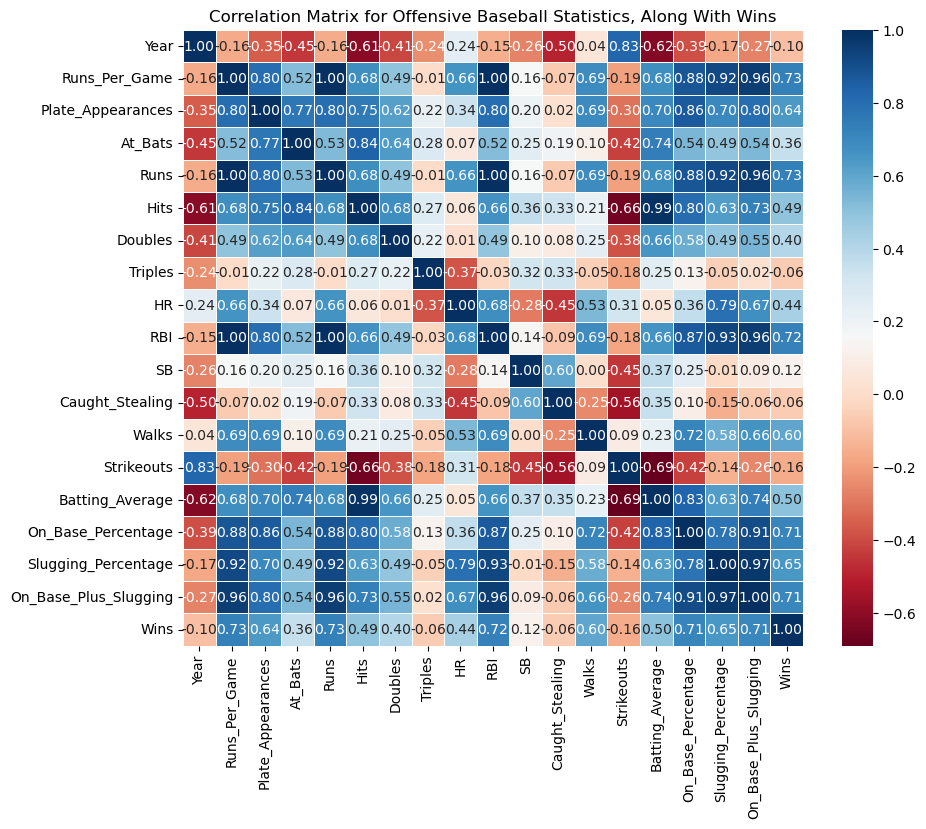

```python
offense_measures = ['Year','Runs_Per_Game','Plate_Appearances', 'At_Bats', 'Runs', 'Hits', 'Doubles', 'Triples', 'HR', 'RBI', 'SB', 'Caught_Stealing', 'Walks', 'Strikeouts', 'Batting_Average', 'On_Base_Percentage', 'Slugging_Percentage', 'On_Base_Plus_Slugging']
defense_measures = ['Year', 'Errors', 'Double_Plays', 'Fielding_Percentage']

# Adding Wins
off_wins = offense_measures + ['Wins']
corr_off = bsbl_df[off_wins].corr()

plt.figure(figsize=(10, 8))
sns.heatmap(corr_off, annot=True, cmap='RdBu', fmt='.2f', linewidths=0.5);
plt.title('Correlation Matrix for Offensive Baseball Statistics, Along With Wins');
```

First, we look at Year to see if it is correlated with wins and any other offensive measures. We see that the correlation value for Year and Wins is -0.1, which is nearly 0, meaning they are not correlated. This backs up our initial thoughts from the graphs above. The only variables that seem to be correlated with Year are Hits, Strikeouts, and Batting Average.

Looking at the Wins row, we see something very interesting. Doubles and Homeruns have just a moderate positive correlation with wins. But, triples has a nearly 0 correlation, meaning wins and triples aren't really correlated at all. Slugging has a 0.65 correlation, which is almost strong, but not quite.

Looking at the other variables, we see that there are some very strong correlations. OBP, Slugging, and OPS are all very strongly positively correlated to Runs Per Game, Runs, and RBI. Batting Average is strongly positively correlated with Hits. All of these make sense because if these measures are high, more runs will score. Runs Per Game is 100% positively correlated with (1.00 correlation value) both Runs and RBIs, which makes sense, since Runs refers to the number of runs and RBIs are runs batting in (runs scoring). Then we get Strikeouts being moderately strongly negatively correlated with Hits and Batting Average. This makes sense also, because if one strikes out, they don't get a hit and their batting average decreases.

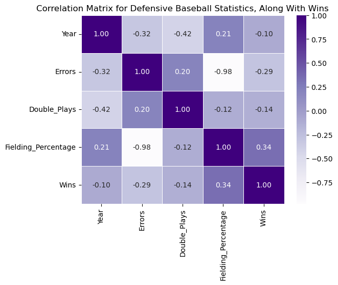

```python
def_wins = defense_measures + ['Wins']
corr_def = bsbl_df[def_wins].corr()

sns.heatmap(corr_def, annot=True, cmap='Purples', fmt='.2f', linewidths=0.5);
plt.title('Correlation Matrix for Defensive Baseball Statistics, Along With Wins');
```

Looking at Year and defensive statistics, we do not see much correlation. This further tells us what we have been speculating earlier, that statistics are not changing at the same time as the Year is.

Lastly, we will look at the spread of Batting Average, OPS, and Fielding Percentage for each team over the years 2002 to 2024.

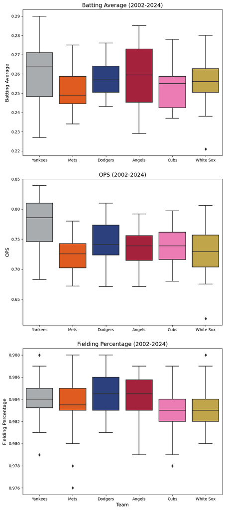

```python
## Specific hex codes to be continuous throughout EDA
team_colors = {
    'Angels': '#BA0C2F',  # Angels Red
    'Dodgers': '#1E3A8A',  # Dodger Blue
    'Cubs': '#FF69B4',     # Giving Cubs hot pink because their colors are too similar to other colors
    'White Sox': '#000000',  # White Sox Black
    'Yankees': '#A8ACAF',  # Yankees Gray
    'Mets': '#FF4F00'      # Mets Orange
}

## Having to change the color of white sox because black blocks out the median line
team_colors['White Sox'] = '#D4AF37'

# Define figure and axes for a 3x1 layout
fig, axes = plt.subplots(3, 1, figsize=(8, 18))

# Plotting the boxplot for Batting Average
sns.boxplot(
    x='Team',
    y='Batting_Average',
    data=bsbl_df,
    palette=team_colors,
    width=0.8,
    ax=axes[0]
)
axes[0].set_title('Batting Average (2002-2024)', fontsize=14)
axes[0].set_xlabel(' ')  # Remove x-axis label for consistency
axes[0].set_ylabel('Batting Average', fontsize=12)

# Plotting the boxplot for OPS
sns.boxplot(
    x='Team',
    y='On_Base_Plus_Slugging',
    data=bsbl_df,
    palette=team_colors,
    width=0.8,
    ax=axes[1]
)
axes[1].set_title('OPS (2002-2024)', fontsize=14)
axes[1].set_xlabel(' ')  # Remove x-axis label for consistency
axes[1].set_ylabel('OPS', fontsize=12)

# Plotting the boxplot for Fielding Percentage
sns.boxplot(
    x='Team',
    y='Fielding_Percentage',
    data=bsbl_df,
    palette=team_colors,
    width=0.8,
    ax=axes[2]
)
axes[2].set_title('Fielding Percentage (2002-2024)', fontsize=14)
axes[2].set_xlabel('Team', fontsize=12)  # Add x-axis label only for the bottom plot
axes[2].set_ylabel('Fielding Percentage', fontsize=12)

# Adjust layout
plt.tight_layout()
plt.show();
```

These three plots tell us a lot about what teams performed better than others over the last 22 seasons.

The boxplots of Batting Average show us some really interesting information. The first thing that pops out to me is the Angels. Their spread from the first to third quartiles of batting average over the 22 years is the largest. This makes sense, because their wins over this time is both inconsistent and erratic. The next thing I see is that the White Sox do have an outlier in terms of batting average, which has been calculated to be the 2024 season. I am not too worried about this value because their lowest end of the bottom whisker is just the second highest behind the dodgers. So, their values by year are not as variable. The Dodgers have the smallest overall spread, meaning they were the most consistent in terms of batting average over the past 22 years. The Yankees have the largest overall spread, meaning they were the least consistent. I am very surprised with the Yankees spread, because their high end being at a .290 batting average is incredibly high and almost unheard of.

The Boxplots for OPS are much more similar to one another. The medians are similar and so are the spreads. The only team that separates itself from the rest is the Yankees. Over the years, the Yankees seem to have a much higher OPS. This tells us that the Yankees are a team with more powerful hitters, or they get walked more. This is because they were similar to the others in average, but they are much higher here. OPS takes into consideration walks, hits by pitch, and slugging percentage, which is why I am able to come to this conclusion. We also see that the White Sox have another outlier. Because batting average is part of OPS, I assume that this outlier is also from year 2024. I notice also that the Mets have the lowest median OPS but also have the shortest spread from the first quartile to the third quartile. I assume this means that the Mets have been consistently the worst team in regards to OPS from the years 2002 to 2024.

Now that we understand how the teams have trended over the past 22 seasons, we can now look at how and if salary affects performance.

### Salary vs. Performance

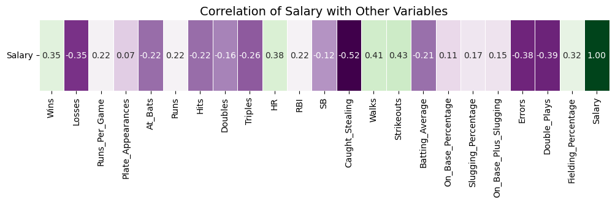

```python
## Creating the Correlation Matrix
# Not including year because it does not make sense for the correlation matrix
corr_salary = bsbl_df.drop(columns=['Year']).corr()

# Select the 'Salary' row as a DataFrame
salary_corr = corr_salary[['Salary']].T  # Transpose to make it horizontal

# Plot the heatmap for just the Salary row
plt.figure(figsize=(12, 1.5))
sns.heatmap(salary_corr, annot=True, cmap='PRGn', fmt='.2f', linewidths=0.5, cbar=False)
plt.title('Correlation of Salary with Other Variables', fontsize=14)
plt.xticks(rotation=90)
plt.yticks(rotation=0)
plt.show();
```

I chose to just look at the Salary row of the correlation matrix because we explored the other correlations earlier. We can see that wins and salaries are not really correlated at all, since the value is only 0.35. The only variable that seems to be a bit correlated with Salary is Caught Stealing at -0.52. This is not strong at all, but it is a negative correlation. So, as salary goes up, caught stealing goes down. Overall, the fact that there isn't much correlation makes sense since salary is not a performance variable. In relation to the initial question of if salary is related to performance, this chart makes it seem as though they are not related at all.

Although we don't see any correlation in terms of salary and performance, they may be similar in trends. If that is the case, it could lead me to believe that there may be some sort of causality or correlation, even though this logic is somewhat flawed. I will now look at the graphical displays of salary and compare them to displays of performance variables. I will line these graphs up next to each other for ease of comparison.

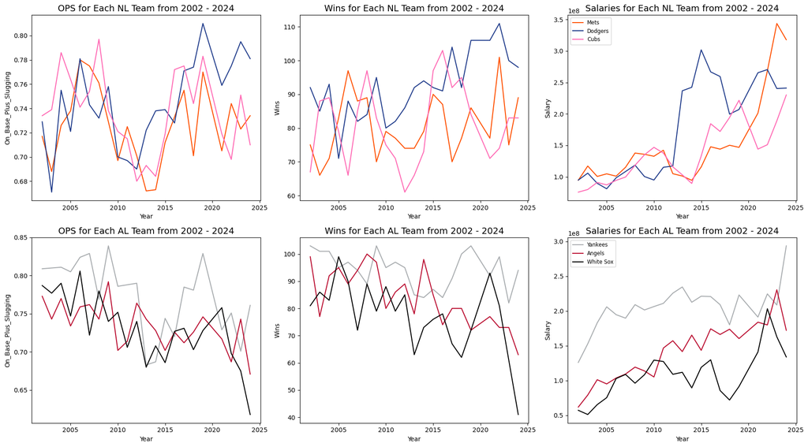

```python
# Prepare the data for NL and AL teams
nl_wins_sal = nl[['Year', 'Team', 'Wins', 'Salary']]
al_wins_sal = al[['Year', 'Team', 'Wins', 'Salary']]
nl_ops_sal = nl[['Year', 'Team', 'On_Base_Plus_Slugging', 'Salary']]
al_ops_sal = al[['Year', 'Team', 'On_Base_Plus_Slugging', 'Salary']]

# 2x3 layout
fig, axes = plt.subplots(2, 3, figsize=(18, 10))

## NL OPS
sns.lineplot(x='Year', y='On_Base_Plus_Slugging', hue='Team', data=nl_ops_sal, ax=axes[0, 0], palette=nl_colors, legend=False)
axes[0, 0].set_title('OPS for Each NL Team from 2002 - 2024', fontsize=14)

## NL Wins
sns.lineplot(x='Year', y='Wins', hue='Team', data=nl_wins_sal, ax=axes[0, 1], palette=nl_colors, legend=False)
axes[0, 1].set_title('Wins for Each NL Team from 2002 - 2024', fontsize=14)

## NL Salary
sns.lineplot(x='Year', y='Salary', hue='Team', data=nl_wins_sal, ax=axes[0, 2], palette=nl_colors)
axes[0, 2].set_title('Salaries for Each NL Team from 2002 - 2024', fontsize=14)
axes[0, 2].legend(fontsize='small', loc='upper left')

## AL OPS
sns.lineplot(x='Year', y='On_Base_Plus_Slugging', hue='Team', data=al_ops_sal, ax=axes[1, 0], palette=al_colors, legend=False)
axes[1, 0].set_title('OPS for Each AL Team from 2002 - 2024', fontsize=14)

## AL Wins
sns.lineplot(x='Year', y='Wins', hue='Team', data=al_wins_sal, ax=axes[1, 1], palette=al_colors, legend=False)
axes[1, 1].set_title('Wins for Each AL Team from 2002 - 2024', fontsize=14)

## AL Salary
sns.lineplot(x='Year', y='Salary', hue='Team', data=al_wins_sal, ax=axes[1, 2], palette=al_colors)
axes[1, 2].set_title('Salaries for Each AL Team from 2002 - 2024', fontsize=14)
axes[1, 2].legend(fontsize='small', loc='upper left')

# Adjust layout
plt.tight_layout()
plt.show();
```

#### Wins vs. Salary

There is really not much we can see from these graphs. Looking at the NL graphs, we can see somewhat of a trend with the Dodgers. With wins, they tend to trend upwards, while the Salary also trends upwards. While the Mets salary trends upwards their wins fluctuate around the middle mostly. While the Cubs Salary also increases, their wins are erratic and inconsistent.

Looking at the Al graphs, we see that the Yankees are at the top for both wins and salary, while the White Sox are at the bottom for both. It is interesting, however, that for both the Angels and the White Sox, the wins are decreasing but the salaries are increasing, which is opposite of what I would initially expect.

One potentially important thing to note is inflation and how money has changed over time. $1,000,000 20 years ago meant more in the economy than it does today. Also, as the MLB continues to grow as a league, there is more money to be spent. I am not sure how much this affects team spending on payroll, but I am sure it has some type of affect. More: https://www.foxsports.com/stories/other/whats-really-behind-mlbs-salary-inflation

#### OPS vs. Salary

We see similar trends with OPS as we did with Wins, especially for AL. Other than those middle years, Yankees have the highest OPS, while they have the highest salary pretty much the entire time. We see the same trend with the Angels and the White Sox: that their OPS is decreasing as their salaries are increasing.

The NL sees a really large dip in performance between the years of 2010 and 2015. However, we see that between those years, the OPS of the Dodgers increased at the same time their salary increased. The OPS fluctuates a lot with the Mets, even though they increased their spending by a large margin towards recent years.

Another thing to note is how performance affects salary. Teams that perform better (whether they win the World Series or the NL/AL Pennant) tend to spend more money in years after success. Here, we don't see this much. We actually see the opposite in some cases. The Dodgers won the NL Pennant in 2015 and then immediately saw a drop in Salary.

##### Does Salary Affect Performance?

Based on the correlation matrix and the graphs above, I do not think we can come to the conclusion that salary affects performance. There were no significant correlation values. Looking at the line graphs, the trends were not noticeably similar.

Lastly, to understand how salary as a whole has been per team, I will look at the boxplots.

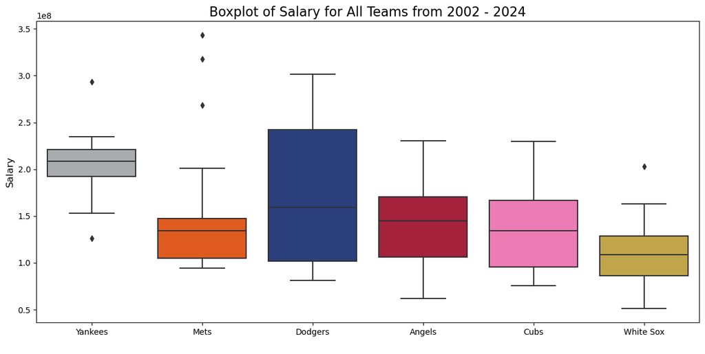

```python
# Plotting the boxplot for Salary for all six teams
plt.figure(figsize=(12, 6))
sns.boxplot(
    x='Team',
    y='Salary',
    data=bsbl_df,
    palette=team_colors,
    width=0.8
)

# Customizing the plot
plt.title('Boxplot of Salary for All Teams from 2002 - 2024', fontsize=16)
plt.xlabel(' ', fontsize=12)
plt.ylabel('Salary', fontsize=12)


# Show the plot
plt.tight_layout(pad=0.5)
plt.show();
```

# Summary

By doing this extensive Exploratory Data Analysis, I was able to learn more about the data I am looking at. I was able to see how some variables predict others, how variables correlate to others, and how variables vary within themselves. I was able to not only look at how teams trend over time, whether it is with offensive measures, defensive measures, wins, or salary, but I was also able to compare the teams.

#### Difficulties

In terms of difficulties with the project, there weren't many. The data was easy to work with because there were no null values. The only somewhat difficult thing to decide was whether or not to include 2020. It may seem obvious to leave it out, which is what I did, but there are some issues with doing so. I think the part of the project that was affected the most by this was the line graphs and the trend analysis. Although the season was cut short and there were no fans, both of which affect performance, they played nonetheless. As explained earlier, teams and players alike are streaky, so this shortened season could have halted a hot streak. The only truly difficult thing has to do with the data and how the MLB works. With 162 games a season, it is tough for a team or players to be really good or really bad, as the high number of games leads to a level out of statistics.

#### Conclusions

There are a few conclusions that can be made from this exploratory data analysis. My first goal was to analyze trend data. In conclusion, the Yankees and Dodgers have been the best overall teams over the last 22 years, while the White Sox have been the worst. The three NL teams dipped pretty significantly between the years 2010 and 2015.

My second goal was to investigate the relationship between salary and performance. I can conclude that there really isn't much of a relationship. Like I said earlier, this makes sense. Players are paid more when they have proved themselves in the past or are big names for the future. Either way, with so many games and how streaky the game is, there is no telling whether a phenomenal performance one year will lead to a phenomenal performance in the next year.

#### Possible Next Steps

One possible next step is to run some machine learning models to see if we can use this data to predict how teams will perform in the 2025 season and beyond. We can also use ML models to predict salary. Another step is to run Natural Language Processing (NLP). We can take anything from Twitter posts to announcer calls and see if the trends of what they say compare to the trends shown in the data above. Lastly, I would say a next step could be to find deeper and more complex data points to add to the analysis. How would more statistical measures affect correlations? How would they affect possible regressions run in the future?